# Expresión diferencial

# edgeR

Para construir la lista de edgeR requerimos indicar cuáles son los grupos que se compararán y el número de réplicas por grupo:

```r
colnames(counts)
```

```
## [1] "A_CT_1" "A_CT_2" "A_CT_3" "B_CT_1" "B_CT_2" "B_CT_3"
```

```r
##Usar los nombres de las columnas de la matriz de cuentas para seleccionar los dos grupos experimentales
groups <- factor(sub("..$", "", colnames(counts)))
table(groups)
```

```
## groups
## A_CT B_CT
##    3    3
```

Crear la lista empleando la matriz de cuentas y los grupos:

```r
edgeRlist <- DGEList(counts = counts,
                     group = groups,
                     genes = rownames(counts))
str(edgeRlist)
```

```
## Formal class 'DGEList' [package "edgeR"] with 1 slot
##   ..@ .Data:List of 3
##   .. ..$ : int [1:12050, 1:6] 998 1274 199 714 0 4761 984 1218 313 1315 ...
##   .. .. ..- attr(*, "dimnames")=List of 2
##   .. .. .. ..$ : chr [1:12050] "ENSG00000000003" "ENSG00000000419" "ENSG00000000457" "ENSG00000000460" ...
##   .. .. .. ..$ : chr [1:6] "A_CT_1" "A_CT_2" "A_CT_3" "B_CT_1" ...
##   .. ..$ :'data.frame':  6 obs. of  3 variables:
##   .. .. ..$ group       : Factor w/ 2 levels "A_CT","B_CT": 1 1 1 2 2 2
##   .. .. ..$ lib.size    : num [1:6] 25791745 35428109 38155734 17030975 15049033 ...
##   .. .. ..$ norm.factors: num [1:6] 1 1 1 1 1 1
##   .. ..$ :'data.frame':  12050 obs. of  1 variable:
##   .. .. ..$ genes: chr [1:12050] "ENSG00000000003" "ENSG00000000419" "ENSG00000000457" "ENSG00000000460" ...
```

Posteriormente los datos de normalizan empleando el método de los [TMM](https://www.youtube.com/watch?v=Wdt6jdi-NQo&t=393s) (weighted Trimmed Mean of M-values). Para ello edgeR busca y elimina los valores atípicos (expresión absoluta de muestra como expresión relativa entre muestra) y calcula los factores de normalización.

```r
edgeRlist <- calcNormFactors(edgeRlist, method = "TMM")
edgeRlist$samples
```

```
##        group lib.size norm.factors
## A_CT_1  A_CT 25791745    1.1130004
## A_CT_2  A_CT 35428109    1.0882614
## A_CT_3  A_CT 38155734    1.0922808
## B_CT_1  B_CT 17030975    0.9605541
## B_CT_2  B_CT 15049033    0.9113970
## B_CT_3  B_CT 36868378    0.8633914
```

Es importante inspeccionar que los datos se encuentren correctamente normalizados. Para ello, las gráficas de la expresión absoluta vs expresión relativa para cada muestra deben tener una forma de “trompeta”:

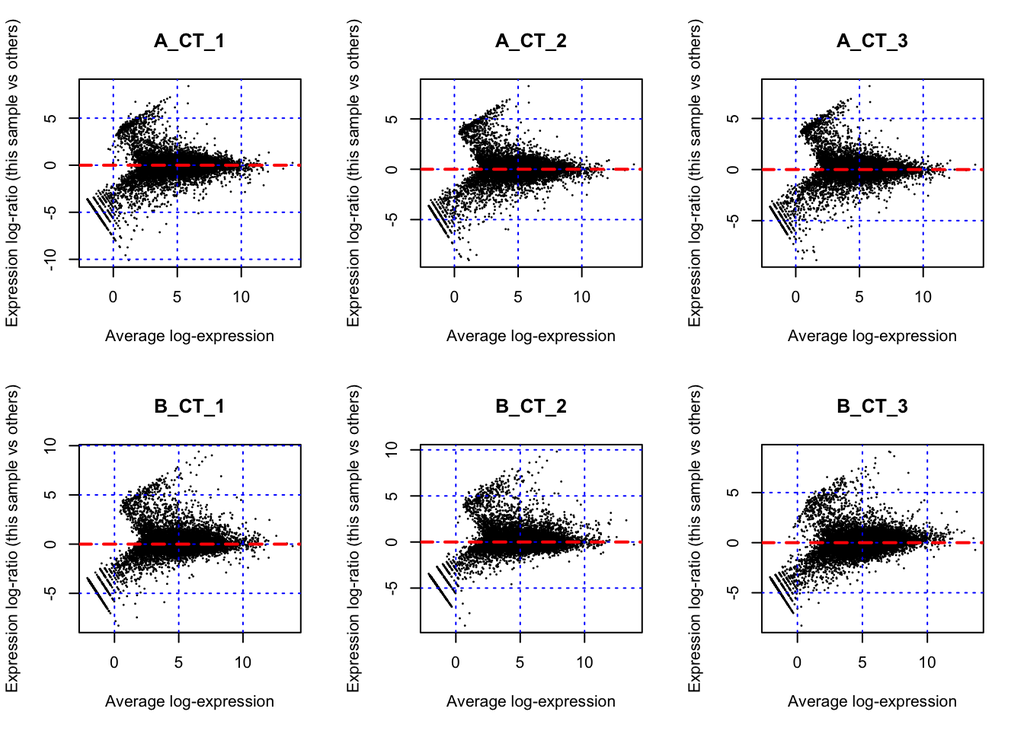

La consistencia de las réplicas la podemos verificar mediante un análisis de componentes principales (PCA) o calculando la correlación (Pearson) que existe entre las muestras:

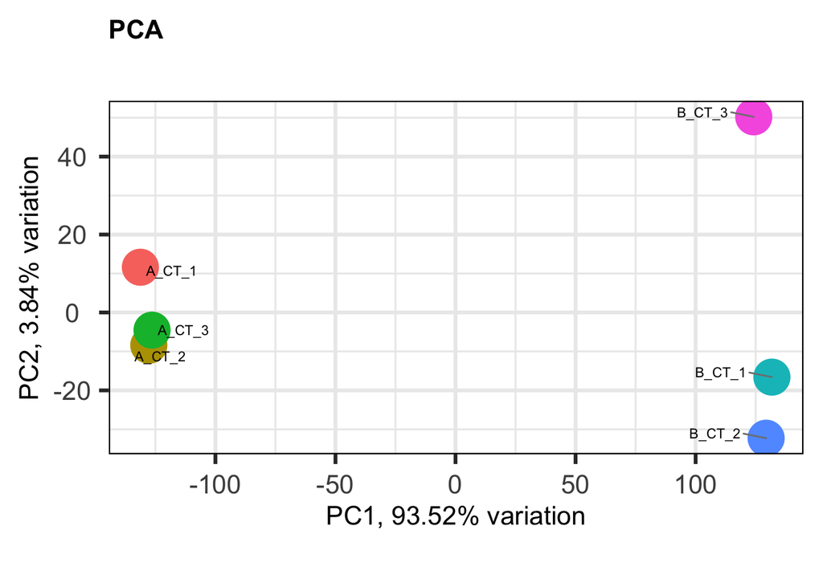

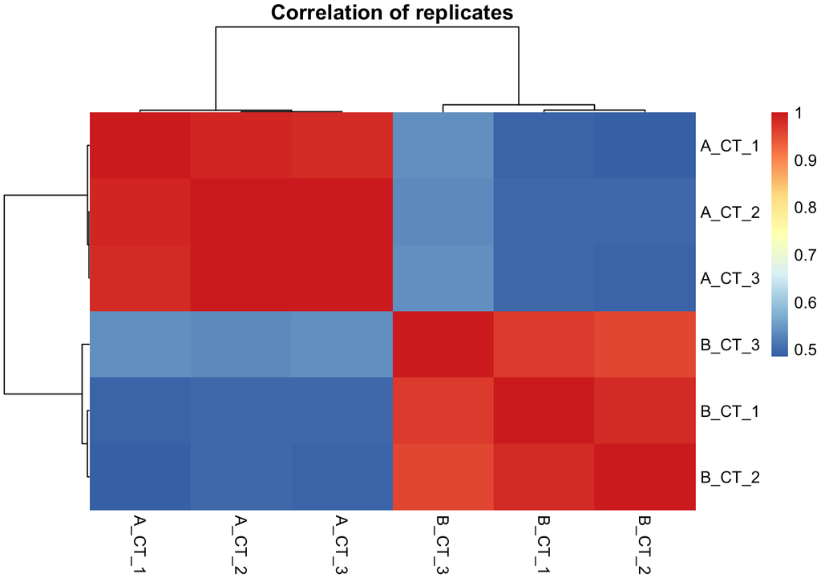

Para el análisis de expresión diferencial requerimos:

- Crear una matriz del diseño experimental
- Calcular la dispersión de los datos
- Crear una matriz de contrastes

## Matriz de diseño experimental

En esta matriz le vamos a indicar a edgeR cuáles muestras corresponden a un grupo o condición experimental. Dado que algunos experimentos pueden tener diseños muy complejos (una muestra pertenece a un tipo celular y a un tratamiento) empleamos la función interna en R de modelado de matrices:

```r
design <- model.matrix(~0+edgeRlist$samples$group)
##El término ~0 le indica a la función no incluir una columna de intersecciones y solamente incluir tantas columnas como grupos en nuestro diseño experimental
colnames(design) <- levels(edgeRlist$samples$group)

design
```

```
##   A_CT B_CT
## 1    1    0
## 2    1    0
## 3    1    0
## 4    0    1
## 5    0    1
## 6    0    1
## attr(,"assign")
## [1] 1 1
## attr(,"contrasts")
## attr(,"contrasts")$`edgeRlist$samples$group`
## [1] "contr.treatment"
```

## Dispersión de los datos

Como edgeR ajusta los datos a un modelo de distribución bi-nomial negativo (parecido a Poisson) se requiere calcular un parámetro adicional de dispersión de los datos.

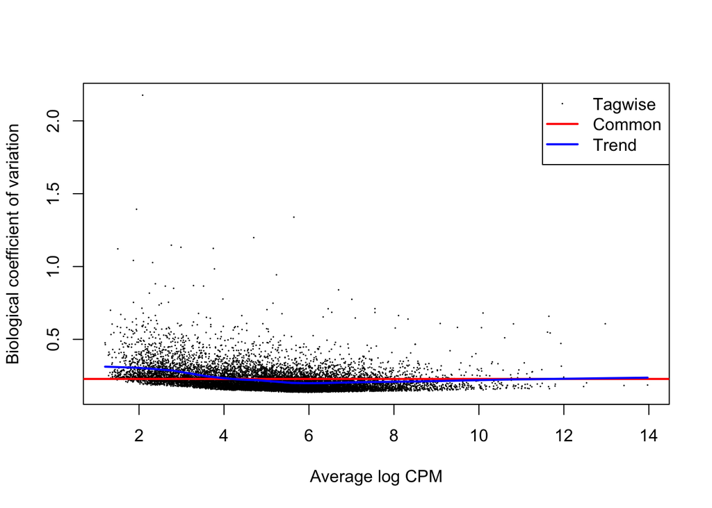

```r
edgeRlist <- estimateDisp(edgeRlist, design = design, robust = T)
plotBCV(edgeRlist)
```

edgeR calcula la dispersión a tres niveles:

- Common. Valor representativo de todos los genes
- Trended. Calculada por rangos de nivel de expresión (expresión baja - expresión alta)
- Tagwise. Valor individual para cada gen

## Matriz de contrastes

edgeR en los análisis de expresión diferencial puede obviar las comparaciones entre los grupos experimentales. Sin embargo, es bueno contar con una matriz de contrastes para indicarle a edgeR cuáles son las comparaciones que queremos hacer entre los datos.

```r
contrast <- makeContrasts(
  "Cells" = "B_CT - A_CT",
  levels = edgeRlist$design
)

contrast
```

```
##       Contrasts
## Levels Cells
##   A_CT    -1
##   B_CT     1
```

En este caso, solo tenemos dos condiciones experimentales “Células A” y “Células B”. Con esta matriz de contrastes indicamos que la comparación será buscando los genes diferencialmente expresados en B con respecto a A. Sin embargo, si tuvieramos mayor cantidad de grupos experimentales los podemos comparar, por ejemplo:

Células CT = X, Y, Z

Células Tx = P, Q, R

`makeContrast("Cells" = "(P + Q + R)/3 - (X, Y, Z)/3")`

El objetivo es que los coeficientes sumen 0

## Análisis de expresión diferencial

Lo primero que tenemos que realizar es ajustar los datos a un modelo lineal bi-nomial negativo. Para ello se utilizará la función `glmQLfit` con la cual se tiene un control más robusto del “error rate”.

```r
fit <- glmQLFit(edgeRlist, design = design, robust = T)
```

Se realiza la comparación para obtener los genes diferencialmente expresados entre una condición y otra. Con la función `glmQLFTest`, estamos probando la hipótesis nula “el valor de lfc del gen A es igual a 0”. Por lo tanto, los valores de p y p.adj calculados están hechos con respecto a dicha hipótesis nula.

```r
qlf.BvsA <- glmQLFTest(fit, ##Objeto en forma de lista con los datos ajustados a un modelo bi-nomial negativo
                       contrast = contrast[, "Cells"]) ##Matriz de contrastes
##Obtenemos los DEG con expresión distinta de 1, valor de p menor a 0.05, corrigiendo el valor de p por el método de Benjamini-Hochberg
deg.BvsA <- decideTestsDGE(qlf.BvsA, p.value = 0.05, adjust.method = "BH", lfc = 0)
table(deg.BvsA)
```

```
## deg.BvsA
##   -1    0    1
## 3307 5244 3499
```

```r
##Guardamos los resultados en un data.frame
DEG.BvsA <- DEGResults(qlf.BvsA)
##Añadimos una columna extra a los resultados anteriores indicando la condición de expresión respecto al lfc y al FDR
DEG.BvsA <- edgeResults(DEG.BvsA, logfc = 0, padj = 0.05)
```

Los datos los visualizamos graficando un **“Volcano plot”**

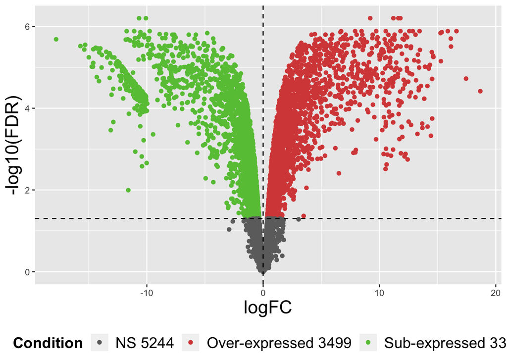

Un procedimiento muy común es seleccionar aquellos genes cuya expresión difeerencial haya sido **significativa** y que cumplan con un valor de lfc. Por ejemplo: |lfc| > 1 (es decir genes con cuya expresión es > 2 o < 0.5 respecto al CT)

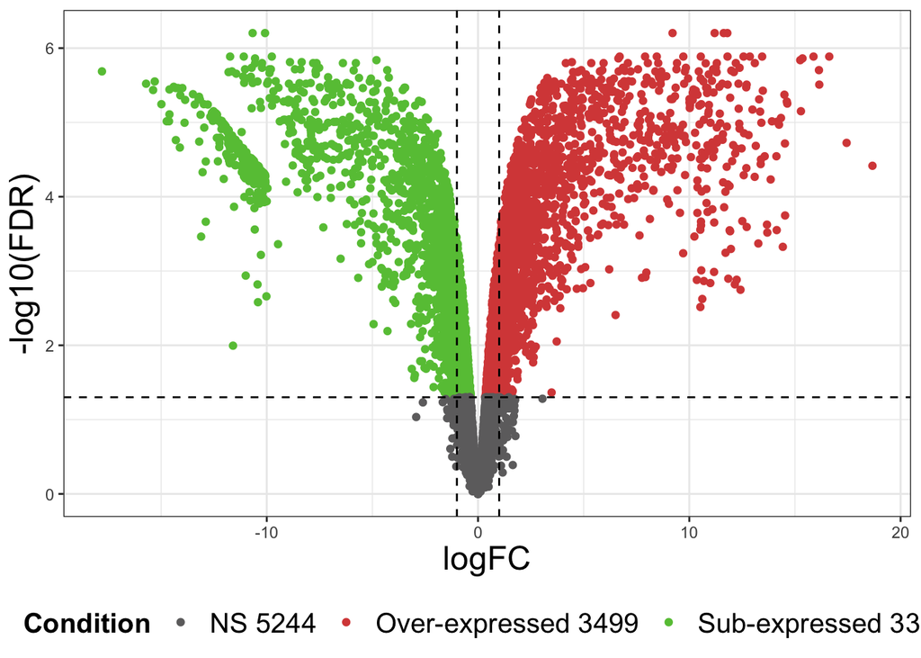

```r
volcano_edgeR(DEG.BvsA, lfc = 1, padj = 0.05)
```

```r
significant.1 <- DEG.BvsA %>% filter(logFC > 1 & FDR < 0.05 | logFC < -1 & FDR < 0.05)
paste(length(significant.1$genes), "is the number of significant genes")
```

```
## [1] "4045 is the number of significant genes"
```

Para resolver este problema, tanto edgeR como DESeq2 implementan funciones en donde se prueba la hipótesis nula “el |lfc| del gen A es distinto a x”:

```r
qlf.BvsA.lfc1 <- glmTreat(fit,
              contrast = contrast[, "Cells"],
              lfc = 1)
deg.BvsA.lfc1 <- decideTestsDGE(qlf.BvsA.lfc1, p.value = 0.05, adjust.method = "BH", lfc = 1)
table(deg.BvsA.lfc1)
```

```
## deg.BvsA.lfc1
##   -1    0    1
## 1198 9405 1447
```

De esta manera podemos seleccionar los genes que estadísticamente tienen |lfc| > 1 y robustecer nuestros resultados.

```r
DEG.BvsA.lfc1 <- DEGResults(qlf.BvsA.lfc1)
DEG.BvsA.lfc1 <- edgeResults(DEG.BvsA.lfc1, logfc = 1, padj = 0.05)
```

Visualizamos estos datos en un nuevo volcano plot

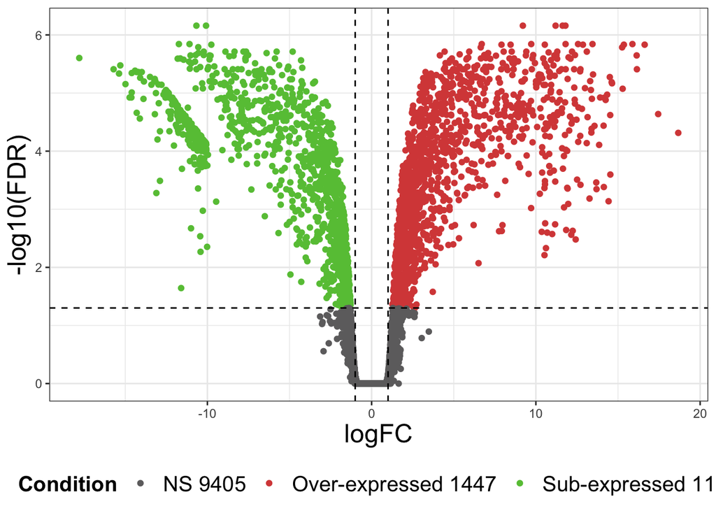

```r
volcano_edgeR(DEG.BvsA.lfc1, lfc = 1, padj = 0.05)
```

```r
significant.genes <- DEG.BvsA.lfc1 %>% filter(FDR < 0.05 & logFC > 1 | FDR < 0.05 & logFC < -1)
paste("The number of significant genes with |lfc| > 1 is", length(significant.genes$genes))
```

```
## [1] "The number of significant genes with |lfc| > 1 is 2645"
```

Finalmente, los los genes diferencialmente expresados podemos emplearlos para crear mapas de calor **“heatmaps”**:

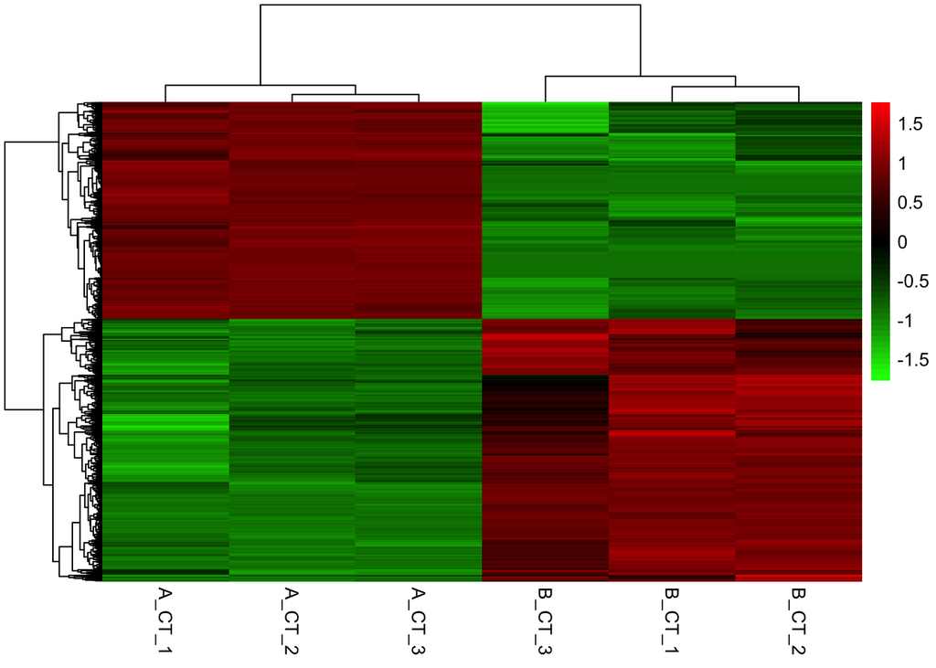

```r
##Obtener los nombres o ids de los genes con expresión diferencial
significant.ids <- significant.genes$genes
##Crear una matriz de cuentas normalizadas por cpm empleando las cuentas que se encuentran guardadas en el objeto edgeRlist
significant.cpm <- cpm(edgeRlist$counts, log = T)
##Cortamos los genes con expresión significativa
significant.cpm <- significant.cpm[significant.ids, ]

##Generamos una paleta de colores
RedBlackGreen <- maPalette(low = "green", high = "red", mid = "black")
##Obtenemos el heatmap
pheatmap(significant.cpm,
         border_color = NA,
         color = RedBlackGreen,
         show_rownames = F,
         scale = "row")
```